# Weather and Corn Yield Regressions

Nathan Mueller

2/25/2022

## Weather Data Analysis

### Load the PRISM daily maximum temperatures

```r
# daily max temperature
# dimensions: counties x days x years
prism <- readMat("data/prismiowa.mat")

# look at county #1
t_1981_c1 <- prism$tmaxdaily.iowa[1,,1]
t_1981_c1[366]
```

```
## [1] NaN
```

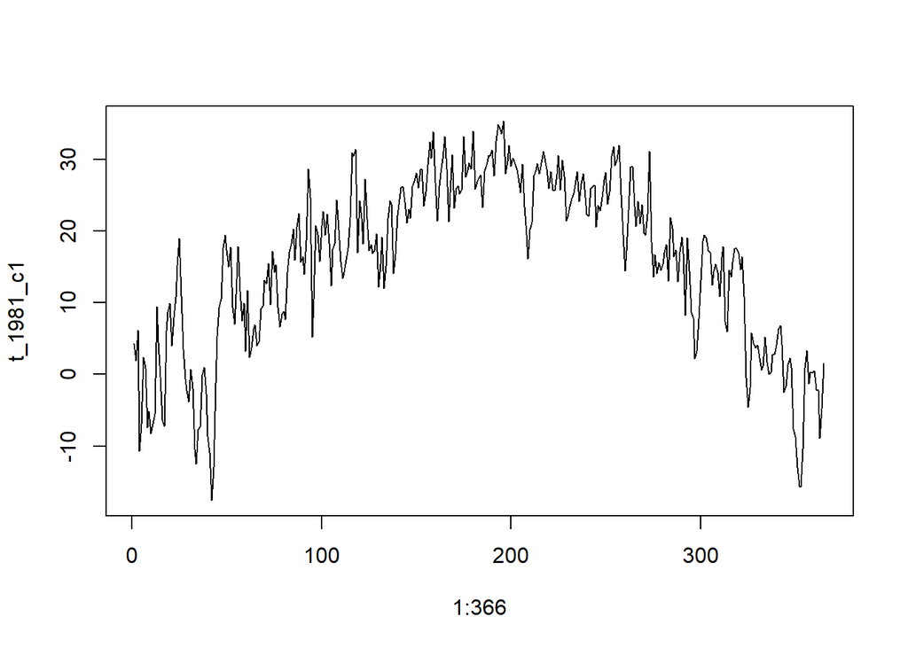

```r
plot(1:366, t_1981_c1, type = "l")
```

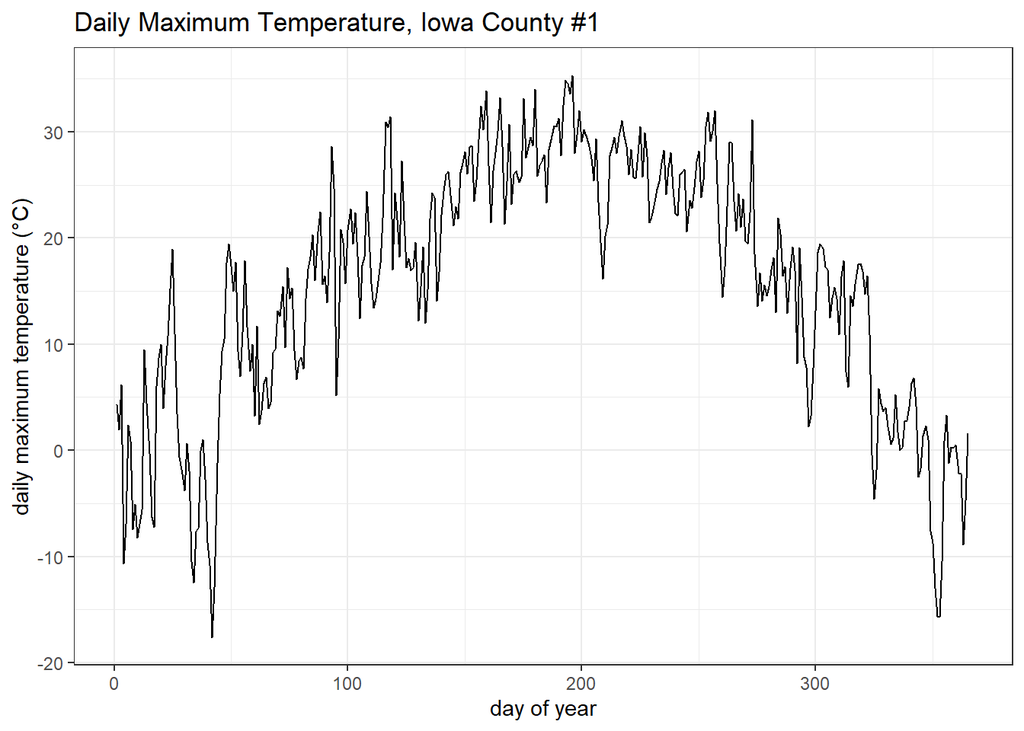

```r
ggplot() +
  geom_line(mapping = aes(x=1:366, y = t_1981_c1)) +
  theme_bw() +
  xlab("day of year") +
  ylab("daily maximum temperature (°C)") +
  ggtitle("Daily Maximum Temperature, Iowa County #1")
```

```r
# assign dimension names to tmax matrix
dimnames(prism$tmaxdaily.iowa) <- list(prism$COUNTYFP, 1:366, prism$years)

# converted 3d matrix into a data frame
tmaxdf <- as.data.frame.table(prism$tmaxdaily.iowa)

# relabel the columns
colnames(tmaxdf) <- c("countyfp","doy","year","tmax")
tmaxdf <- tibble(tmaxdf)
```

## Temperature trends

### Summer temperature trends: Winneshiek County

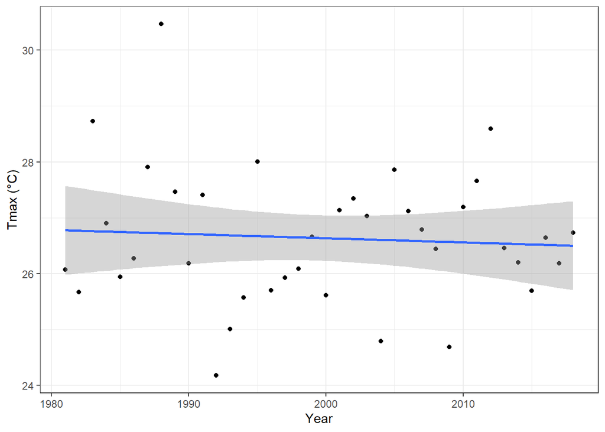

```r
tmaxdf$doy <- as.numeric(tmaxdf$doy)
tmaxdf$year <- as.numeric(as.character(tmaxdf$year))

winnesummer <- tmaxdf %>%
  filter(countyfp==191 & doy >= 152 & doy <= 243) %>%
  group_by(year) %>%
  summarize(meantmax = mean(tmax))

ggplot(winnesummer, mapping = aes(x = year, y = meantmax)) +
  geom_point() +
  theme_bw() +
  labs(x = "Year", y = "Tmax (°C)") +
  geom_smooth(method = lm)
```

```r
lm_summertmax <- lm(meantmax ~ year, winnesummer)
summary(lm_summertmax)
```

```
##
## Call:
## lm(formula = meantmax ~ year, data = winnesummer)
##
## Residuals:
##     Min      1Q  Median      3Q     Max
## -2.5189 -0.7867 -0.0341  0.6859  3.7415
##
## Coefficients:
##             Estimate Std. Error t value Pr(>|t|)
## (Intercept) 41.57670   36.44848   1.141    0.262
## year        -0.00747    0.01823  -0.410    0.684
##
## Residual standard error: 1.232 on 36 degrees of freedom
## Multiple R-squared:  0.004644,   Adjusted R-squared:  -0.02301
## F-statistic: 0.168 on 1 and 36 DF,  p-value: 0.6844
```

### Winter Temperatures - Winneshiek County

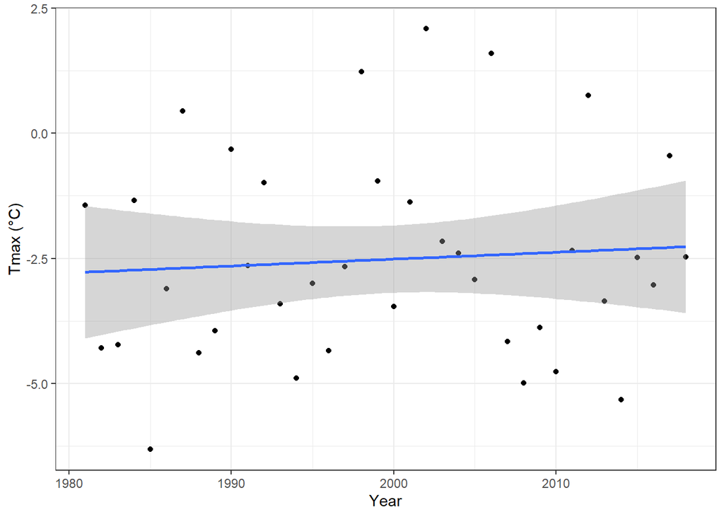

```r
winnewinter <- tmaxdf %>%
  filter(countyfp==191 & (doy <= 59 | doy >= 335) & !is.na(tmax)) %>%
  group_by(year) %>%
  summarize(meantmax = mean(tmax))

ggplot(winnewinter, mapping = aes(x = year, y = meantmax)) +
  geom_point() +
  theme_bw() +
  labs(x = "Year", y = "Tmax (°C)") +
  geom_smooth(method = lm)
```

```r
lm_wintertmax <- lm(meantmax ~ year, winnewinter)
summary(lm_wintertmax)
```

```
##
## Call:
## lm(formula = meantmax ~ year, data = winnewinter)
##
## Residuals:
##     Min      1Q  Median      3Q     Max
## -3.5978 -1.4917 -0.3053  1.3778  4.5709
##
## Coefficients:
##              Estimate Std. Error t value Pr(>|t|)
## (Intercept) -29.87825   60.48100  -0.494    0.624
## year          0.01368    0.03025   0.452    0.654
##
## Residual standard error: 2.045 on 36 degrees of freedom
## Multiple R-squared:  0.005652,   Adjusted R-squared:  -0.02197
## F-statistic: 0.2046 on 1 and 36 DF,  p-value: 0.6537
```

### Multiple regression – Quadratic time trend

```r
# Squares the year value
winnewinter$yearsq <- winnewinter$year^2

# Fitting Linear Model to the year(sq) plus year.
lm_wintertmaxquad <- lm(meantmax ~ year + yearsq, winnewinter)
summary(lm_wintertmaxquad)
```

```
##
## Call:
## lm(formula = meantmax ~ year + yearsq, data = winnewinter)
##
## Residuals:
##     Min      1Q  Median      3Q     Max
## -3.3539 -1.2985 -0.2813  1.4055  4.2620
##
## Coefficients:
##               Estimate Std. Error t value Pr(>|t|)
## (Intercept) -1.086e+04  1.238e+04  -0.877    0.386
## year         1.085e+01  1.239e+01   0.876    0.387
## yearsq      -2.710e-03  3.097e-03  -0.875    0.388
##
## Residual standard error: 2.051 on 35 degrees of freedom
## Multiple R-squared:  0.02694,    Adjusted R-squared:  -0.02867
## F-statistic: 0.4845 on 2 and 35 DF,  p-value: 0.6201
```

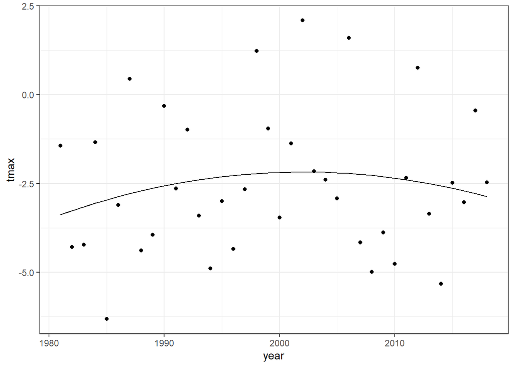

```r
# Fitting the linear model to the original winter df:
winnewinter$fitted <- lm_wintertmaxquad$fitted.values

#plotting the winter df with the linear model
ggplot(winnewinter) +
  geom_point(mapping = aes(x = year, y = meantmax)) +
  geom_line(mapping = aes(x = year, y = fitted)) +
  theme_bw() +
  labs(x = "year", y = "tmax")
```

### Download NASS corn yield data

## Assignment

### Question 1a:

Extract Winneshiek County corn yields, fit a linear time trend, make a plot. Is there a significant time trend?

*The trend over the period of record shows a positive relationship between the yield of corn produced over time in Winneshiek, IA. The relevant statistic show the trend to be significant (p-value: 1.767e-13) with an R-squared of 0.749.*

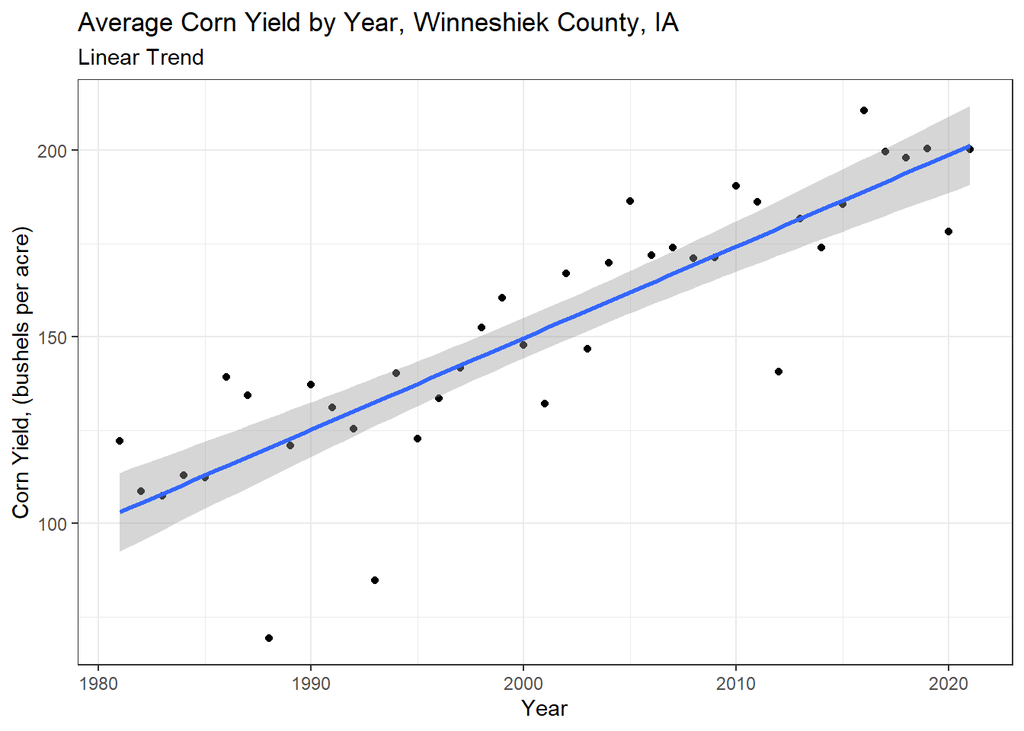

```r
#Filtering for Winneshiek county
winne_corn <- cornyields %>%
  filter(county_name == "WINNESHIEK")

ggplot(winne_corn, mapping = aes(x = year, y = yield)) +
  geom_point() +
  theme_bw() +
  labs(x = "Year", y = "Corn Yield, (bushels per acre)") +
  geom_smooth(method = lm) +
  labs(title = "Average Corn Yield by Year, Winneshiek County, IA", subtitle = "Linear Trend")
```

```r
lm_winne_corn <- lm(yield ~ year, winne_corn)
summary(lm_winne_corn)
```

```
##
## Call:
## lm(formula = yield ~ year, data = winne_corn)
##
## Residuals:
##     Min      1Q  Median      3Q     Max
## -51.163  -1.841   2.363   9.437  24.376
##
## Coefficients:
##              Estimate Std. Error t value Pr(>|t|)
## (Intercept) -4763.290    448.286  -10.63 4.46e-13 ***
## year            2.457      0.224   10.96 1.77e-13 ***
## ---
## Signif. codes:  0 '***' 0.001 '**' 0.01 '*' 0.05 '.' 0.1 ' ' 1
##
## Residual standard error: 16.97 on 39 degrees of freedom
## Multiple R-squared:  0.7551, Adjusted R-squared:  0.7488
## F-statistic: 120.2 on 1 and 39 DF,  p-value: 1.767e-13
```

### Question 1b:

Fit a quadratic time trend (i.e., year + year^2) and make a plot. Is there evidence for slowing yield growth?

```r
# Squares the year value
winne_corn$yearsq <- winne_corn$year^2

# Fitting Linear Model to the year(sq) plus year.
lm_winne_corn_quad <- lm(yield ~ year + yearsq, winne_corn)
summary(lm_winne_corn_quad)
```

```
##
## Call:
## lm(formula = yield ~ year + yearsq, data = winne_corn)
##
## Residuals:
##     Min      1Q  Median      3Q     Max
## -51.384  -3.115   1.388   9.743  25.324
##
## Coefficients:
##               Estimate Std. Error t value Pr(>|t|)
## (Intercept)  2.583e+04  8.580e+04   0.301    0.765
## year        -2.812e+01  8.576e+01  -0.328    0.745
## yearsq       7.641e-03  2.143e-02   0.357    0.723
##
## Residual standard error: 17.17 on 38 degrees of freedom
## Multiple R-squared:  0.7559, Adjusted R-squared:  0.7431
## F-statistic: 58.84 on 2 and 38 DF,  p-value: 2.311e-12
```

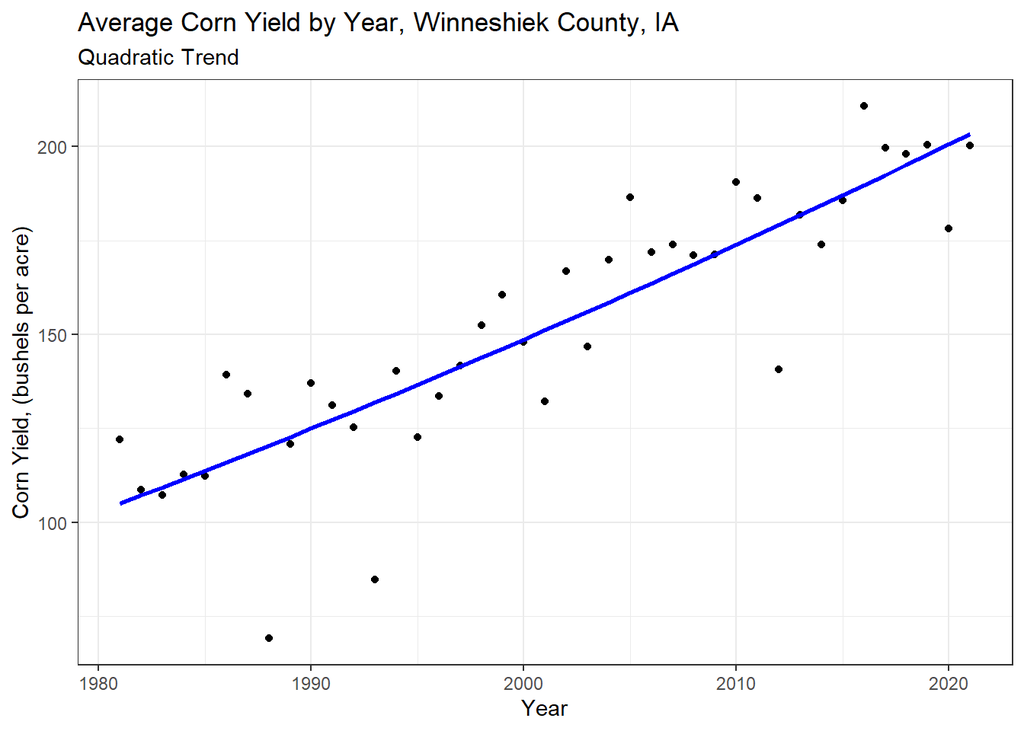

```r
# Fitting the linear model to the original winter df:
winne_corn$fitted <- lm_winne_corn_quad$fitted.values

#plotting the winter df with the linear model
ggplot(winne_corn) +
  geom_point(mapping = aes(x = year, y = yield)) +
  geom_line(mapping = aes(x = year, y = fitted), color = "blue", size = 1) +
  theme_bw() +
  labs(x = "Year", y = "Corn Yield, (bushels per acre)") +
  labs(title = "Average Corn Yield by Year, Winneshiek County, IA", subtitle = "Quadratic Trend")
```

### Question 2

– Time Series: Let’s analyze the relationship between temperature and yields for the Winneshiek County time series. Use data on yield and summer avg Tmax. Is adding year or Tmax^2 to your model helpful? Make a plot and interpret the results.

```r
#Want to join the tmaxdf to the corn yields df, then plot the two of them together...

#tmax is daily data, can filter by year. can use corn yield by year as well....

# *Use summer avg Tmax*

winn_summer_corn <- cornyields %>%
  filter(county_name == "WINNESHIEK") %>%
  arrange(year)

winn_summer_corn_temp <- left_join(winn_summer_corn,winnesummer, by='year') %>%
  filter(!is.na(meantmax))

# Fitting Linear Model to the yield using year.
lm_winn_summer_corn_temp <- lm(yield ~ year, winn_summer_corn_temp)
summary(lm_winn_summer_corn_temp)
```

```
##
## Call:
## lm(formula = yield ~ year, data = winn_summer_corn_temp)
##
## Residuals:
##     Min      1Q  Median      3Q     Max
## -50.700  -2.623   2.662   9.134  24.575
##
## Coefficients:
##               Estimate Std. Error t value Pr(>|t|)
## (Intercept) -4924.8563   511.2021  -9.634 1.67e-11 ***
## year            2.5376     0.2557   9.925 7.58e-12 ***
## ---
## Signif. codes:  0 '***' 0.001 '**' 0.01 '*' 0.05 '.' 0.1 ' ' 1
##
## Residual standard error: 17.28 on 36 degrees of freedom
## Multiple R-squared:  0.7324, Adjusted R-squared:  0.7249
## F-statistic: 98.51 on 1 and 36 DF,  p-value: 7.584e-12
```

```r
# Fitting the linear model to the original winter df:
winn_summer_corn_temp$fitted_year <- lm_winn_summer_corn_temp$fitted.values

# Squares the tmax value
winn_summer_corn_temp$meantmaxsq <- winn_summer_corn_temp$meantmax^2

# Fitting Linear Model to the meantmax(sq) plus meantmax.
lm_winn_summer_corn_temp2 <- lm(yield ~ meantmax + meantmaxsq, winn_summer_corn_temp)
summary(lm_winn_summer_corn_temp2)
```

```
##
## Call:
## lm(formula = yield ~ meantmax + meantmaxsq, data = winn_summer_corn_temp)
##
## Residuals:
##     Min      1Q  Median      3Q     Max
## -56.587 -22.262  -0.982  22.409  52.798
##
## Coefficients:
##              Estimate Std. Error t value Pr(>|t|)
## (Intercept) -4223.604   1446.639  -2.920  0.00609 **
## meantmax      328.918    107.068   3.072  0.00410 **
## meantmaxsq     -6.173      1.979  -3.119  0.00362 **
## ---
## Signif. codes:  0 '***' 0.001 '**' 0.01 '*' 0.05 '.' 0.1 ' ' 1
##
## Residual standard error: 29.5 on 35 degrees of freedom
## Multiple R-squared:  0.2417, Adjusted R-squared:  0.1984
## F-statistic: 5.579 on 2 and 35 DF,  p-value: 0.007887
```

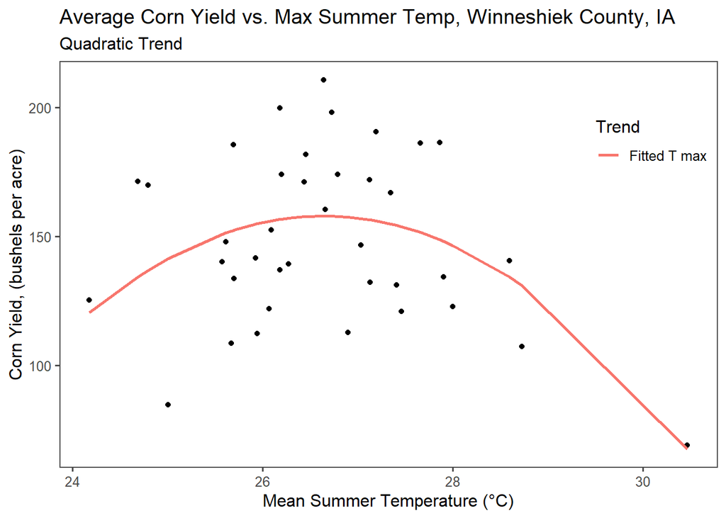

```r
# Fitting the linear model to the original winter df:
winn_summer_corn_temp$fitted_max <- lm_winn_summer_corn_temp2$fitted.values
winn_summer_corn_temp$fitted_year <- lm_winn_summer_corn_temp$fitted.values


#plotting the winter df with the linear model. Fitted year commented out.
ggplot(winn_summer_corn_temp) +
  geom_point(mapping = aes(x = meantmax, y = yield)) +
  geom_line(mapping = aes(x = meantmax, y = fitted_max, color = "Fitted T max"), size = 1) +
  #geom_line(mapping = aes(x = meantmax, y = fitted_year, color = "Year"), size = 1) +
    theme_few() +
  labs(x = "Mean Summer Temperature (°C)", y = "Corn Yield, (bushels per acre)") +
  theme(legend.position = c(0.9,0.8)) +
  labs(color="Trend")+
  labs(title = "Average Corn Yield vs. Max Summer Temp, Winneshiek County, IA", subtitle = "Quadratic Trend")
```

### Question 3

– Cross-Section: Analyze the relationship between temperature and yield across all counties in 2018. Is there a relationship? Interpret the results.

*For 2018, the corn yield for all counties in Iowa had a negative trend for an increase in temperature. The trend is not significant however, and weakly correlated (Adjusted R-squared: 0.02687, p-value: 0.063).*

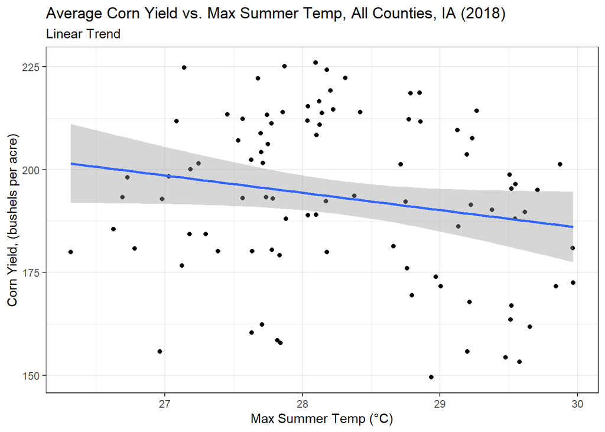

```r
# Want yield for all counties, 2018:
county_yield <- cornyieldsall %>%
  filter(year == 2018) %>%
  group_by(county_name) %>%
  unique() %>%
  filter(!is.na(county_ansi))

#Want maximum summer temperatures (presumably) for 2018, per county.
county_summer <- tmaxdf %>%
  group_by(countyfp) %>%
  filter(year == 2018) %>%
  filter(doy >= 152 & doy <= 243) %>%
  summarize(meantmax = mean(tmax)) %>%
  rename(county_ansi = "countyfp")

county_summer$county_ansi <- as.numeric(as.character(county_summer$county_ansi))

#Joining the two dfs together
county_summer_yield <- left_join(county_yield,county_summer, by='county_ansi')# %>%

#plot
ggplot(county_summer_yield, mapping = aes(x = meantmax, y = yield)) +
  geom_point() +
  theme_bw() +
  labs(x = "Max Summer Temp (°C)", y = "Corn Yield, (bushels per acre)") +
  geom_smooth(method = lm) +
  labs(title = "Average Corn Yield vs. Max Summer Temp, All Counties, IA (2018)", subtitle = "Linear Trend")
```

```r
# Fitting Linear Model to the yield and mean T max:.
lm_county_summer_yield <- lm(yield ~ meantmax, county_summer_yield)
summary(lm_county_summer_yield)
```

```
##
## Call:
## lm(formula = yield ~ meantmax, data = county_summer_yield)
##
## Residuals:
##     Min      1Q  Median      3Q     Max
## -42.983 -15.041   0.955  16.795  31.999
##
## Coefficients:
##             Estimate Std. Error t value Pr(>|t|)
## (Intercept)  312.466     63.387   4.929 3.69e-06 ***
## meantmax      -4.216      2.241  -1.882   0.0631 .
## ---
## Signif. codes:  0 '***' 0.001 '**' 0.01 '*' 0.05 '.' 0.1 ' ' 1
##
## Residual standard error: 19.64 on 91 degrees of freedom
## Multiple R-squared:  0.03745,    Adjusted R-squared:  0.02687
## F-statistic: 3.541 on 1 and 91 DF,  p-value: 0.06308
```

### Question 4

– Panel: One way to leverage multiple time series is to group all data into what is called a “panel” regression. Convert the county ID code (“countyfp” or “county_ansi”) into factor using as.factor, then include this variable in a regression using all counties’ yield and summer temperature data. How does the significance of your temperature coefficients (Tmax, Tmax^2) change? Make a plot comparing actual and fitted yields and interpret the results of your model.

```r
# Want yield for all counties, all years:
county_yield_panel <- cornyieldsall %>%
  group_by(county_name) %>%
  unique() %>%
  filter(!is.na(county_ansi))

#Want maximum summer temperatures per county.
county_summer_panel <- tmaxdf %>%
  group_by(countyfp) %>%
  filter(doy >= 152 & doy <= 243) %>%
  summarize(meantmax = mean(tmax)) %>%
  rename(county_ansi = "countyfp")

county_summer_panel$county_ansi <- as.numeric(as.character(county_summer_panel$county_ansi))

#Joining the two dfs together
county_summer_yield_panel <- left_join(county_yield_panel,county_summer_panel, by='county_ansi')


# combined yield and summer temperature df for all counties
county_summer_yield_panel <- subset(county_summer_yield_panel, select = c(county_ansi, yield, meantmax, year))

#making the county_ansi into a factor:
county_summer_yield_panel$county_ansi <- as.factor(county_summer_yield_panel$county_ansi)

#confirming it is a factor
#str(county_summer_yield_panel$county_ansi)

# Squares the tmax value
county_summer_yield_panel$meantmaxsq <- county_summer_yield_panel$meantmax^2

lm_county_summer_yield_panel <- lm(yield ~ county_ansi + meantmax + meantmaxsq + year, county_summer_yield_panel)

summary(lm_county_summer_yield_panel)
```

```
##
## Call:
## lm(formula = yield ~ county_ansi + meantmax + meantmaxsq + year,
##     data = county_summer_yield_panel)
##
## Residuals:
##      Min       1Q   Median       3Q      Max
## -101.016   -9.576    3.141   14.498   52.720
##
## Coefficients: (2 not defined because of singularities)
##                  Estimate Std. Error t value Pr(>|t|)
## (Intercept)    -4.447e+03  5.773e+01 -77.031  < 2e-16 ***
## county_ansi3   -4.038e+00  4.822e+00  -0.838 0.402346
## county_ansi5    1.137e+01  4.762e+00   2.387 0.017012 *
## county_ansi7   -1.875e+01  4.791e+00  -3.913 9.27e-05 ***
## county_ansi9    9.961e+00  4.762e+00   2.092 0.036510 *
## county_ansi11   1.214e+01  4.762e+00   2.550 0.010815 *
## county_ansi13   1.400e+01  4.762e+00   2.940 0.003305 **
## county_ansi15   1.794e+01  4.762e+00   3.767 0.000168 ***
## county_ansi17   1.907e+01  4.762e+00   4.006 6.30e-05 ***
## county_ansi19   1.618e+01  4.762e+00   3.398 0.000687 ***
## county_ansi21   1.527e+01  4.762e+00   3.207 0.001352 **
## county_ansi23   1.620e+01  4.762e+00   3.403 0.000674 ***
## county_ansi25   1.611e+01  4.762e+00   3.384 0.000721 ***
## county_ansi27   1.444e+01  4.762e+00   3.032 0.002443 **
## county_ansi29   7.471e+00  4.762e+00   1.569 0.116740
## county_ansi31   1.950e+01  4.762e+00   4.095 4.30e-05 ***
## county_ansi33   1.259e+01  4.762e+00   2.643 0.008249 **
## county_ansi35   1.961e+01  4.791e+00   4.094 4.32e-05 ***
## county_ansi37   1.136e+01  4.762e+00   2.385 0.017131 *
## county_ansi39  -2.391e+01  4.854e+00  -4.926 8.76e-07 ***
## county_ansi41   1.311e+01  4.762e+00   2.752 0.005948 **
## county_ansi43   1.667e+01  4.762e+00   3.502 0.000468 ***
## county_ansi45   1.564e+01  4.762e+00   3.285 0.001027 **
## county_ansi47   1.308e+01  4.762e+00   2.748 0.006032 **
## county_ansi49   1.140e+01  4.762e+00   2.394 0.016730 *
## county_ansi51  -1.835e+01  4.791e+00  -3.829 0.000130 ***
## county_ansi53  -1.692e+01  4.854e+00  -3.485 0.000497 ***
## county_ansi55   1.784e+01  4.762e+00   3.746 0.000182 ***
## county_ansi57   9.205e+00  4.791e+00   1.921 0.054767 .
```

[output cut: 64 more lines]

```
## county_ansi187  2.026e+01  4.762e+00   4.254 2.15e-05 ***
## county_ansi189  1.695e+01  4.762e+00   3.560 0.000375 ***
## county_ansi191  1.315e+01  4.762e+00   2.761 0.005792 **
## county_ansi193  6.556e+00  4.762e+00   1.377 0.168630
## county_ansi195  1.511e+01  4.762e+00   3.174 0.001517 **
## county_ansi197  1.816e+01  4.762e+00   3.813 0.000139 ***
## meantmax               NA         NA      NA       NA
## meantmaxsq             NA         NA      NA       NA
## year            2.292e+00  2.881e-02  79.557  < 2e-16 ***
## ---
## Signif. codes:  0 '***' 0.001 '**' 0.01 '*' 0.05 '.' 0.1 ' ' 1
##
## Residual standard error: 21.43 on 3915 degrees of freedom
## Multiple R-squared:  0.6579, Adjusted R-squared:  0.6493
## F-statistic: 76.05 on 99 and 3915 DF,  p-value: < 2.2e-16
```

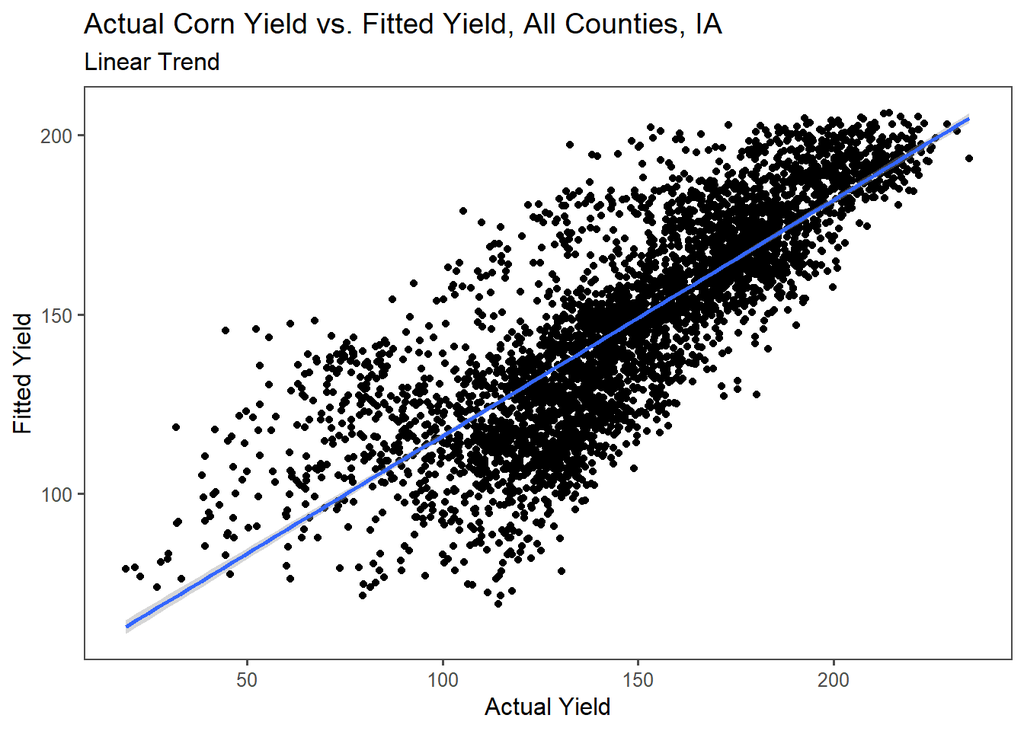

```r
#str(county_summer_yield)
#head(county_summer_yield_panel)

county_summer_yield_panel$fitted <- lm_county_summer_yield_panel$fitted.values

#plotting the df with the linear and fitted model
ggplot(county_summer_yield_panel) +
  geom_point(mapping = aes(x = yield, y = fitted)) +
  geom_smooth(mapping = aes(x = yield, y = fitted),method = lm) +
  theme_few() +
  labs(x = "Actual Yield", y = "Fitted Yield") +
  labs(title = "Actual Corn Yield vs. Fitted Yield, All Counties, IA", subtitle = "Linear Trend")
```